# Obligatorio de Taller de Aprendizaje Automático

Leticia Suarez (202006) y Doris Medina (241578)

13 de junio de 2019

## 1. Entendimiento del caso de negocio y planificación del trabajo

**Planteo del problema**  
Rest-on es una guía turística que está armando en su web una sección de restoranes, que sirva para asesorar a sus clientes en las características y calidad de los restoranes. A estos efectos, los contratan a ustedes para apoyarlos en los algoritmos de soporte de su web, con dos objetivos: * Poder recomendarles a sus clientes restoranes similares a los que han consultado * Rankear a los restoranes, en términos relativos a los restoranes comparables. A estos efectos, cuenta con una base de datos de restoranes, a la cual se puede acceder en el siguiente link: https://archive.ics.uci.edu/ml/datasets/Restaurant+%26+consumer+data

### 1.1 Discuta el desafío planteado en términos de la importancia que tiene para una empresa cualquiera y para Rest-on en particular

Ofrecer recomendaciones que generan valor para los clientes es un objetivo para Rest-ON. No es solo recomendar una opción al cliente, sino que esta desarrolle una conexión con la marca y los clientes vean en la empresa un asesoramiento fundamentado. Por tanto, es objetivo realizar un este análisis permitiendo que los clientes no solo encuentren lo que están buscando, sino que se identifiquen con el servicio. Este desafio está presente en todas aquellas empresas en que su valor de negocio esté vinculado con la fidelidad de los clientes que trabajan con la marca.

### 1.2 Identifique conceptual y técnicamente qué tipo de modelos serían necesarios para atender este problema

Para ofrecer una información que genere valor para el cliente se deben clasificar correctamente los restaurantes a partir de las características que estos poseen y los servicios que ofrece, también se puede tener en cuenta las características propias de los usuarios que visitan los restaurantes que permita realizar una segmentación en función de las características de los usuarios. Todo dependerá del análisis del negocio detallando donde se identifique las variables que pueden formar parte de la segmentación de los restaurantes y poder ofrecer una calidad del servicio superior a los turistas que vienen a recibir la experiencia de Rest-ON.

### 1.3 Plantee hipótesis respecto a qué dimensiones de análisis y variables pueden ser relevantes para lograr el objetivo

Analizando el modelo de negocio de la empresa planteamos como hipótesis que: Para ofrecer mejores recomendaciones es necesario conocer las características de los restaurantes, entender que tipos de cliente asisten y establecer las peculiaridades de la comida que ofrecen

**Dimensiones propuestas:**  
* Características de los restaurantes  
* Características de la comida  
* Datos de los clientes que concurren

**Como variables dentro de cada dimensión identificamos las siguientes:**  
* Características de la comida: Esta dimensión abarca las particularidades de la comida respecto al tipo de menú, la forma en que se sirve, restricciones alimenticias, entre otros.  
* Características de los restaurantes – aquí se recoge la tipología del restaurante, en relación a aspectos operativos y físicos, tales como ubicación, disponibilidad de estacionamiento, medios de pagos aceptados, y otras cualidades que lo hagan atractivo.  
* Datos del cliente: Deberíamos conocer el perfil y las costumbres de los clientes que concurren al restaurante, que nos permita clasificarlos teniendo en cuenta características de los clientes que concurren y en qué modo lo hacen.  
*Ejemplo: Si es con familia, o amigos, si prefieren un ambiente relajado, etc*

### 1.4 Identifique, en base a lo anterior, qué tipo de datos precisaría obtener para llevar a cabo este trabajo

> Ver anexo *Datos Complementarios.xlsx* la pestaña **Varibles Propuestas**

### 1.5 Arme un plan de trabajo, identificando las diferentes etapas y actividades para lograr el objetivo

Se propone para el desarrollo de esta investigación utilizar la metodología CRISP–DM que abarca desde el entendimiento del negocio hasta el despliegue de la solución sin dejar de lado las tareas de gestión de proyectos que permiten el monitoreo y control del tiempo, costos y riesgos asociados.  
De acuerdo con la metodología CRISP-DM se proponen las siguientes fases:

1. Comprensión del negocio
2. Comprensión de los datos
3. Preparación de los datos
4. Modelado
5. Evaluación
6. Implementación

**Comprensión del negocio:** El plan para esta fase consta de comprender el negocio y los objetivos comerciales de la empresa. Adicionalmente abarcaremos tareas tales como describir el problema que se desea resolver, la naturaleza del negocio y el aporte que se desea obtener con el trabajo. Comprensión de los datos: Se realizará un análisis de todos los dataset, revisando las variables y cantidad de registros de cada uno de ellos, presencia de N/A, estructura de los datos, errores en los mismos y utilidad que aporta cada una de las variables para el objetivo del trabajo.

**Preparación de los datos:** En función de los resultados obtenidos en la fase anterior trabajaremos en la transformación de los datos para obtener las variables en el formato adecuado, crear nuevas a partir de la transformación de las ya existentes, y corrección mediante alguna metodología de los registros con NA.

**Modelado:** En esta etapa se evaluarán los modelos a utilizar para realizar el análisis de cluster de los restaurantes. Por la naturaleza del problema se tratará de un modelo no supervisado. Evaluaremos modelos aglomerativos y divisivos. Evaluación: Se utilizarán técnicas como silueta y elbow para ajustar los modelos y verificar los resultados.

**Implementación:** Por último se pondrá el modelo a disposición para ser utilizado evaluando la forma más eficiente de hacerlo.  
Si bien todas las etapas comentadas anteriormente se hacen en forma secuencial, el modelo prevé la posibilidad de regresar a una fase anterior para revisarla y retomar nuevamente el proceso.

**Gestión de proyecto**  
Para la implementación del proyecto se realizará entre el equipo un control de toda la versión del proyecto y se generará un repositorio para el seguimiento y control de código. Utilizando buenas prácticas se reduce la posible generación de errores en los controles de cambio.Utilizaremos Github para realizar el seguimiento de las versiones de la documentación.

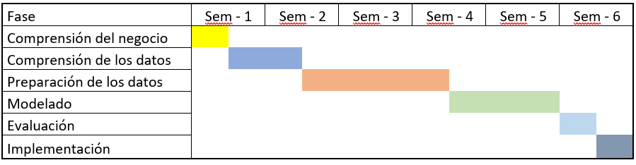

### 1.6 ¿Cómo será utilizado el resultado del trabajo por el cliente?

El resultado o solución va a ser utilizado por la agencia turística para incluirlo en su motor de búsqueda y ofrecer un servicio que beneficie a sus usuarios, generando más volumen de visitas a su sitio y fidelizándolos.

También será usado por los asesores de la empresa que utilizarán el sitio para ofrecer a los vacacionistas mejores recomendaciones según sus necesidades y las características de los restaurantes.

Los restaurantes en la medida que este motor de búsqueda y recomendaciones tenga mayor difusión se beneficiarán por tener mayor publicidad y el perfil de clientes que se sienta más cómodo respecto la propuesta que ofrece.

El usuario en la medida que el motor de búsqueda sea reconocido y fiable en cuanto a las recomendaciones podrá disfrutar de opciones más adecuadas a sus preferencias.

### 1.7 En base a lo anterior, ¿Qué áreas se deberían involucrar en el proyecto y qué rol cumplirían?

Para la ejecución exitosa del proyecto tendrían que participar todas las áreas que estarán en el ciclo completo del proyecto, desde la definición hasta su puesta en producción y mantenimiento del proyecto.

Entre las áreas identificadas están comercial, marketing y el área de soporte técnico que son quienes más conocen a los usuarios de la guía. Por otro lado el área de operaciones y IT al conocer como manejar la gestión de la empresa realizarán la captura y recopilación de los datos de los diferentes restaurantes. Finalmente, el área financiera deberá verificar los impactos económicos de las iniciativas y el equipo de Analistas de Datos para interactuar con los restantes interlocutores.

## 2. Extracción, Transformación o Carga de datos

### 2.1 Diseñe la estructura de tabla datos analítica: ¿qué va a ser cada fila? cuáles van a ser las columnas.

La tabla analítica resultante de esta etapa contará de ID de restaurantes en las filas y variables en las columnas.

> Ver anexo *Datos complementarios.xlsx* la pestaña **Tabla**

### 2.2 ¿Cómo se construye cada una de las variables en la tabla de datos? ¿De qué tablas surge y qué transformaciones de datos son necesarias?

En el archivo adjunto “Datos complementarios.xlsx” se especifican las características de las variables seleccionadas, cuál será la fuente de información y que transformación se le hará a cada una.

> Ver anexo *Datos complementarios.xlsx* la pestaña **Tabla**

### 2.3 Construya la tabla de datos analíticas en base a la especificación anterior

Finalmente se ensamblan todas las variable en la tabla analítica a partir de los ID de restaurantes de la tabla de geoplaces. Esto es debido a que a pesar de que tiene notoriamente menos registros que los restantes dataset, contiene información muy relevante al momento de realizar el cluster, por lo que decidimos reducir la cantidad de restaurantes en pos de enriquecer el análisis.  
Se trabaja en la corrección de los registros con NA en las variables donde están presentes definiéndolos con un valor diferente a los existentes de forma de tenerlos identificados.

A modo aclaratorio comentamos que los dataset de los usuarios no fueron utilizados ya que no están identificados como usuarios de los diferentes restaurantes por lo que no aportan información relevante para el perfil de clientes.

Adicionalmente las caracteristicas contenidas en los mismos como ser medios de pagos y perfil de clientes ya esta presente en los datasets de los restaurantes.

A continuación se detalla todo el proceso de ETL realizado para cada una de las variables.

**Preparación del entrono de trabajo**  
Se cargan todas las librerías a ser utilizadas

#### 2.1 - Transformación de datos de ubicación

Para analizar las distancias gegráficas de los restaurantes se analiza la fuente de datos geoplaces2.csv que tiene un 21 variables para analizar. A continuación se muestran las carateristicas de las vaiables, tipos de datos y framento de valores a partir de la función *srt*

```r
geoplaces <- read.csv ("Dataset/geoplaces2.csv", sep = ',')
str(geoplaces)
```

```
## 'data.frame':    130 obs. of  21 variables:
##  $ placeID       : int  134999 132825 135106 132667 132613 135040 132732 132875 132609 135082 ...
##  $ latitude      : num  18.9 22.1 22.1 23.8 23.8 ...
##  $ longitude     : num  -99.2 -101 -101 -99.2 -99.2 ...
##  $ the_geom_meter: Factor w/ 130 levels "0101000020957F000000DD3546816E5AC119D4BD17FD544A41",..: 67 14 54 49 70 15 68 69 81 80 ...
##  $ name          : Factor w/ 129 levels "Abondance Restaurante Bar",..: 41 73 31 54 12 82 122 111 69 46 ...
##  $ address       : Factor w/ 100 levels "?","16 de Septiembre",..: 77 42 90 23 62 25 24 1 88 98 ...
##  $ city          : Factor w/ 17 levels "?","Cd Victoria",..: 6 9 12 17 16 12 2 1 16 12 ...
##  $ state         : Factor w/ 13 levels "?","mexico","morelos",..: 4 5 9 12 13 11 13 1 13 11 ...
##  $ country       : Factor w/ 3 levels "?","mexico","Mexico": 3 2 3 1 3 3 3 1 3 3 ...
##  $ fax           : Factor w/ 1 level "?": 1 1 1 1 1 1 1 1 1 1 ...
##  $ zip           : Factor w/ 35 levels "?","62000","62170",..: 1 22 11 1 1 10 35 1 1 30 ...
##  $ alcohol       : Factor w/ 3 levels "Full_Bar","No_Alcohol_Served",..: 2 2 3 2 2 3 2 3 2 2 ...
##  $ smoking_area  : Factor w/ 5 levels "none","not permitted",..: 1 1 3 1 4 1 1 5 2 1 ...
##  $ dress_code    : Factor w/ 3 levels "casual","formal",..: 3 3 3 3 3 3 1 3 3 3 ...
##  $ accessibility : Factor w/ 3 levels "completely","no_accessibility",..: 2 1 3 1 1 2 1 2 1 2 ...
##  $ price         : Factor w/ 3 levels "high","low","medium": 3 2 3 2 3 1 2 1 2 3 ...
##  $ url           : Factor w/ 14 levels "?","carlosandcharlies.com",..: 5 1 1 1 1 1 1 1 1 1 ...
##  $ Rambience     : Factor w/ 2 levels "familiar","quiet": 1 1 1 1 1 1 1 1 2 1 ...
##  $ franchise     : Factor w/ 2 levels "f","t": 1 1 1 2 2 1 1 2 2 1 ...
##  $ area          : Factor w/ 2 levels "closed","open": 1 2 2 1 1 1 2 2 1 1 ...
##  $ other_services: Factor w/ 3 levels "Internet","none",..: 2 2 2 2 2 2 2 1 2 2 ...
```

Las primeras variables dentro de este set de datos que será analizadas son latitud(latitude) y longitud(longitude). A continuación se grafican los puntos para identificar como están distribuidas.

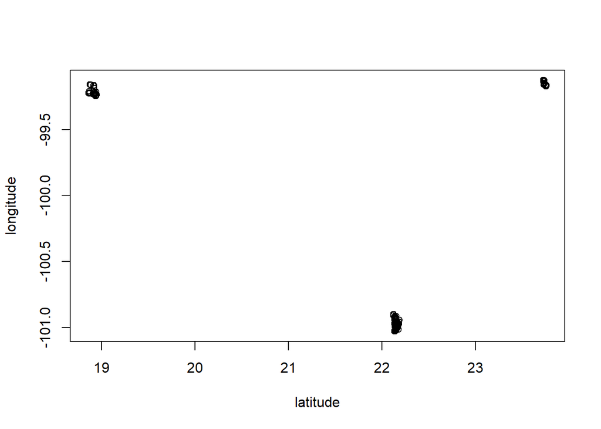

```r
geoCoord <- geoplaces[,1:3]
plot(geoCoord[,2:3])
```

Analizando como se gráfica las coordenadas podemos plantear que los restaurantes estan separado en 3 cuidades diferentes. Visualmente se identificicaron los punto de referencias aproximados y se contrastaron con su ubicación en el mapa para seleccionar los puntos. Se debe definir las distancias entre los restaurantes y 3 puntos de referencia para establecer un marco comparativo entre las posiciones de los resutantes y los puntos de referencia.Los puntos de referencia elegidos arbitrariamente fueron: 22.156925, -100.985634 (San Luis Potosí) 18.924490, -99.221556 (Morelos) 23.732142, -99.148336 (Victoria.Tamaulipas)

```r
#Creando los puntos de referencia
point1 <- matrix(c(22.156925,-100.985634),ncol=2)
point2 <- matrix(c(18.924490,-99.221556),ncol=2)
point3 <- matrix(c(23.732142,-99.148336),ncol=2)

#Convertir a matrix las coordenadas
mtxPoints <- data.matrix(geoCoord[,2:3])

#Calculando las distancias
distPoint1 <- t(spDists(point1, mtxPoints, longlat = TRUE))
distPoint2 <- t(spDists(point2, mtxPoints, longlat = TRUE))
distPoint3 <- t(spDists(point3, mtxPoints, longlat = TRUE))

#Creando dataframe con todos los resultados
dfDistance <- data.frame(placeID=geoplaces$placeID,distPoint1=distPoint1,distPoint2=distPoint2,distPoint3 = distPoint3)

#Obtener el index del valor mínimo que representa la ciudad permitiendo agruparlas
for (i in seq(nrow(dfDistance))) {
  pCoord <- c(dfDistance$distPoint1[i],dfDistance$distPoint2[i],dfDistance$distPoint3[i])
  dfDistance$classCity[i] <- if(as.numeric(which.min(pCoord)) == 1) {"A"} else if (as.numeric(which.min(pCoord)) == 2) {"B"} else "C"
}
head(dfDistance)
```

```
##   placeID  distPoint1 distPoint2 distPoint3 classCity
## 1  134999 210.7491874   4.099599  85.770393         B
## 2  132825   0.3488594 206.499412 207.169042         A
## 3  135106   1.0762984 205.762946 206.388126         A
## 4  132667 205.8273963  86.362182   1.716889         C
## 5  132613 205.6389491  86.359610   1.905332         C
## 6  135040   1.8348958 204.994784 205.723112         A
```

Entre los datos identificados en la fuente de datos geoplaces2.csv se encuentra la variable smoking_area la cual fue analizada e identificamos los siguientes valores únicos: none, not permitted,only at bar,permitted,section). Vamos a transformar esta variable en lógica para establecer si el restaurante permite o no fumar bajo ciertas condiciones. Se realizá un conversión a valores True para only_at_bar, permitted, section and False para los demás

```r
# Se carga la variable a analizar.
smokingPlace <- geoplaces[,c("placeID","smoking_area")]
levels(smokingPlace$smoking_area)
```

```
## [1] "none"          "not permitted" "only at bar"   "permitted"
## [5] "section"
```

```r
smokingPlace$smoking_area <- tolower(smokingPlace$smoking_area)

#Se identifica si el restaurante entra o no en la clasificación de fumadores.
for (i in seq(nrow(smokingPlace))) {
  smokingPlace$isSmoking[i] <- if(smokingPlace$smoking_area[i] == "only at bar"
                           || smokingPlace$smoking_area[i] == "permitted"
                           || smokingPlace$smoking_area[i] == "section") T else F
}

smokingPlace$smoking_area <- NULL

# Se muestran los primero 10 registros
head(smokingPlace,10)
```

```
##    placeID isSmoking
## 1   134999     FALSE
## 2   132825     FALSE
## 3   135106      TRUE
## 4   132667     FALSE
## 5   132613      TRUE
## 6   135040     FALSE
## 7   132732     FALSE
## 8   132875      TRUE
## 9   132609     FALSE
## 10  135082     FALSE
```

*Analisis de los tipos de comida

Analizamos la variable Rcuisine de la base chefmozcuisine.csv donde se identifica 59 tipos de comidas distribuida entre todos los restaurantes. Un restaurante puede tener varios tipos de comida. A continuación se muestra el resumen de los datos cargados y un ejemplo de 6 valores.

```r
chefmozcuisine <- read.csv ("Dataset/chefmozcuisine.csv", sep = ',')
str(chefmozcuisine)
```

```
## 'data.frame':    916 obs. of  2 variables:
##  $ placeID : int  135110 135109 135107 135106 135105 135104 135103 135103 135103 135103 ...
##  $ Rcuisine: Factor w/ 59 levels "Afghan","African",..: 53 36 40 42 28 42 13 22 28 34 ...
```

```r
head(chefmozcuisine)
```

```
##   placeID       Rcuisine
## 1  135110        Spanish
## 2  135109        Italian
## 3  135107 Latin_American
## 4  135106        Mexican
## 5  135105      Fast_Food
## 6  135104        Mexican
```

Se realiza una reclasifacion utilizando pareto para reducir la cantidad de factores.

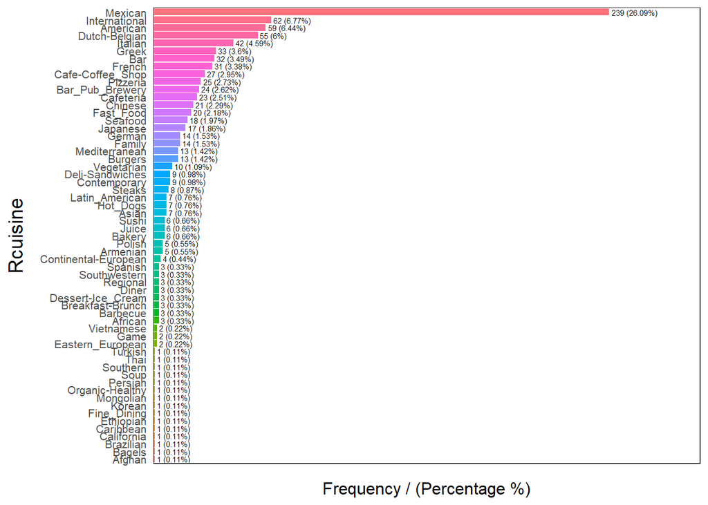

```
##            Rcuisine frequency percentage cumulative_perc
## 1           Mexican       239      26.09           26.09
## 2     International        62       6.77           32.86
## 3          American        59       6.44           39.30
## 4     Dutch-Belgian        55       6.00           45.30
## 5           Italian        42       4.59           49.89
## 6             Greek        33       3.60           53.49
## 7               Bar        32       3.49           56.98
## 8            French        31       3.38           60.36
## 9  Cafe-Coffee_Shop        27       2.95           63.31
## 10         Pizzeria        25       2.73           66.04
## 11  Bar_Pub_Brewery        24       2.62           68.66
## 12        Cafeteria        23       2.51           71.17
## 13          Chinese        21       2.29           73.46
## 14        Fast_Food        20       2.18           75.64
## 15          Seafood        18       1.97           77.61
## 16         Japanese        17       1.86           79.47
## 17           Family        14       1.53           81.00
## 18           German        14       1.53           82.53
## 19          Burgers        13       1.42           83.95
## 20    Mediterranean        13       1.42           85.37
```

```r
head(freq(chefmozcuisine, "Rcuisine"), 20)
```

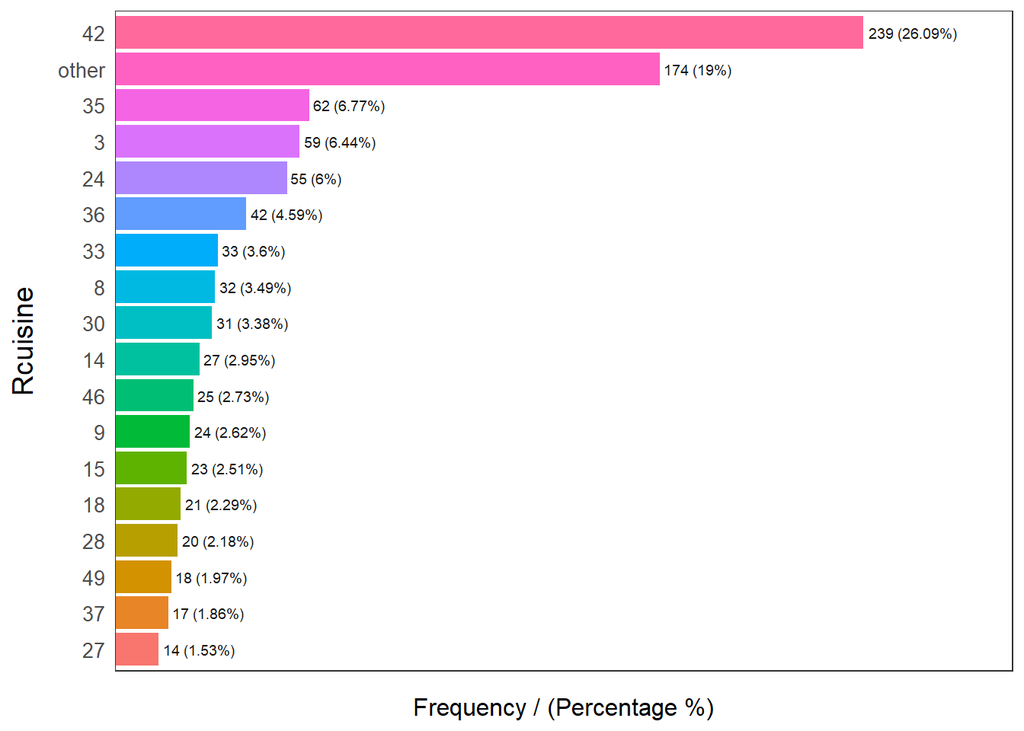

```
##    Rcuisine frequency percentage cumulative_perc
## 1        42       239      26.09           26.09
## 2     other       174      19.00           45.09
## 3        35        62       6.77           51.86
## 4         3        59       6.44           58.30
## 5        24        55       6.00           64.30
## 6        36        42       4.59           68.89
## 7        33        33       3.60           72.49
## 8         8        32       3.49           75.98
## 9        30        31       3.38           79.36
## 10       14        27       2.95           82.31
## 11       46        25       2.73           85.04
## 12        9        24       2.62           87.66
## 13       15        23       2.51           90.17
## 14       18        21       2.29           92.46
## 15       28        20       2.18           94.64
## 16       49        18       1.97           96.61
## 17       37        17       1.86           98.47
## 18       27        14       1.53          100.00
```

```r
cuisine_freq = freq(chefmozcuisine, "Rcuisine", plot = F)

chefmozcuisineFrc <- chefmozcuisine
chefmozcuisineFrc$Rcuisine = ifelse(chefmozcuisineFrc$Rcuisine %in% cuisine_freq[1:17,'Rcuisine'], chefmozcuisineFrc$Rcuisine, 'other')
freq(chefmozcuisineFrc, 'Rcuisine')
```

Un corte razonable sería a partir del 80% de los datos, pero esto implicaria quedarnos con 17 variables (las transformaremos en variables debido a que los restaurantes en general aplican a más de un tipo de comida por lo que tienen más de una fila para cada ID). Por otra parte observamos que existen varios tipos de comidas similares entre ellos, por lo que decidimos agruparlos generando una reclasificación para quedarnos con menos variables.

```r
#Grupos de comidas
chefmozcuisineAgg <- read.csv ("Dataset/Cuisine_agrupado.csv", sep = ';')
names(chefmozcuisineAgg)[2] <- "TypeCuisine"
# a continuación se unen ambas tablas conservando todas las filas del dataset original y agregando
# la columna con la nueva clasificación.
chefmozcuisineClass <- left_join(chefmozcuisine,chefmozcuisineAgg, by="Rcuisine")

# adicionalmente se elimina la columna con la clasificacion anterior y todas las filas que quedaron
# con igual clasificacion para el mismo ID
chefmozcuisineClass <- unique(chefmozcuisineClass[,-2])
chefmozcuisineClass <-

# luego de correr los modelos detectamos que al poner como variables los tipos de comida, todos los restaurantes que aparecían con NA por no tener ese tipo de comida y posteriormente pasarlos a "Otros" se clusterizaron juntos debido a la alta frecuencia del atributo. Por tal razón decidimos seguir trabajando en agruparlos para no perder información y transformarlos en una variable única. Luego de este trabajo solo 5 restaurantes perdieron un tipo de comida y en varios casos el segundo tipo era "otro" por lo que tampoco se perdio información relevante.
chefmozcuisineClass[!duplicated(chefmozcuisineClass[,c("placeID")]),]

head(chefmozcuisineClass, 10)
```

```
##    placeID TypeCuisine
## 1   135110     Europea
## 2   135109     Europea
## 3   135107    American
## 4   135106     Mexican
## 5   135105   Fast_Food
## 6   135104     Mexican
## 7   135103   Fast_Food
## 11  135102    American
## 14  135101     Mexican
## 16  135100     Mexican
```

```r
str(chefmozcuisineClass)
```

```
## 'data.frame':    769 obs. of  2 variables:
##  $ placeID    : int  135110 135109 135107 135106 135105 135104 135103 135102 135101 135100 ...
##  $ TypeCuisine: Factor w/ 9 levels "American","Asian",..: 5 5 1 8 6 8 6 1 8 8 ...
```

A partir de analisis anterior consideramos que aporta información de negocio determinar la cantidad de tipos de comida que ofrecen los restaurantes partiendo de la base que a mayor cantidad de ofertas permite un publico mas variado. Para esto utilizamos el dataset original en lugar del agrupado.

```r
chefmozcuisineCont <-chefmozcuisine%>%
                      group_by(placeID)%>%
                      count(placeID)

names(chefmozcuisineCont)[2] <- "foodCount"
head(chefmozcuisineCont)
```

```
## # A tibble: 6 x 2
## # Groups:   placeID [6]
##   placeID foodCount
##     <int>     <int>
## 1  132001         1
## 2  132002         1
## 3  132003         1
## 4  132004         1
## 5  132005         2
## 6  132006         1
```

Se analizan los días de atención de los restaurantes. Se concluye que no aporta información relevante porque más del 99% tiene atención los 7 días de la semana, por lo que se decide eliminar la variable del análsis.

```r
# chefmozhours4_mod <- read.csv ("Dataset/chefmozhours4_modificado.csv", sep = ',')
# str(chefmozhours4_mod)
# #Levantar datos de dias de atencion y guardar
# #
#
# chefmozhours4_mod$Days1 <- ifelse(chefmozhours4_mod$Days1 == "Mon", 1, (chefmozhours4_mod$Days1))
#
# # se eliminan las columnas con los restantes dias de la semana (tue-fri) y las filas repetidas
#
# chefmozhours4_mod <- unique(chefmozhours4_mod[,-3:-6])
# chefmozhours4_mod1 <- tidyr::spread(data = chefmozhours4_mod, key = Days1, value = Days1)
# chefmozhours4_mod1[,2:4] <- ifelse(chefmozhours4_mod1[,2:4] == "NA" , F , T)
# names(chefmozhours4_mod1) <- c("placeID", "L-V", "S", "D")
```

Otras de las variable a analizar es si tiene parking o no el restaurante. Cuando se carga los datos se identificaron 7 factores donde se distribuyen los datos. En ese caso se consideró crear una nueva variable logica donde se guarde TRUE cuando sean los valores fee, public, valet parking, validated parking, yes y FALSE cuando sea igual none o street.

```r
#Levantar datos de parking y guardar
chefmozparking <- read.csv ("Dataset/chefmozparking.csv", sep = ',')

#Se identificaron los valores para el factor parking_lot
levels(chefmozparking$parking_lot)
```

```
## [1] "fee"               "none"              "public"
## [4] "street"            "valet parking"     "validated parking"
## [7] "yes"
```

```r
#Cuando sea street se convierte a none porque se considera que no se clasifica como que tiene parqueo.
chefmozparking$parking_lot[chefmozparking$parking_lot == "street"] <- "none"

#Se crea una nueva variable parking_lot
chefmozparking$hasParking <- (ifelse(chefmozparking$parking_lot == "none", F, T))
chefmozparking$parking_lot <- NULL
head(chefmozparking)
```

```
##   placeID hasParking
## 1  135111       TRUE
## 2  135110      FALSE
## 3  135109      FALSE
## 4  135108      FALSE
## 5  135107      FALSE
## 6  135106      FALSE
```

```r
str(chefmozparking)
```

```
## 'data.frame':    702 obs. of  2 variables:
##  $ placeID   : int  135111 135110 135109 135108 135107 135106 135105 135104 135103 135102 ...
##  $ hasParking: logi  TRUE FALSE FALSE FALSE FALSE FALSE ...
```

```r
#Levantar datos de medios de pago aceptados y guardar
chefmozaccepts <- read.csv ("Dataset/chefmozaccepts.csv", sep = ',')

#Llevar todo a mayúscula y luego nos quedamos con los registros unicos
chefmozaccepts$Rpayment <- toupper(chefmozaccepts$Rpayment)
chefmozaccepts <- unique(chefmozaccepts)

#Genero el mismo set de datos para utilizar posteriormente
chefmozacceptsCant <- chefmozaccepts


# # Se normaliza todos los valores de medio de pago
# chefmozaccepts <- tidyr::spread(data = chefmozaccepts, key = Rpayment, value = Rpayment)
# print(colnames(chefmozaccepts))
#
# #Seleccionamos las columnas que mantendremos
# varsToKeep <- c("placeID",  "AMERICAN_EXPRESS", "BANK_DEBIT_CARDS", "CASH", "MASTERCARD-EUROCARD", "VISA")
# chefmozaccepts <- chefmozaccepts[,varsToKeep]
# chefmozaccepts[,2:6] <- ifelse(is.na(chefmozaccepts[,2:6]) == T , F , T)
# head(chefmozaccepts, 10)
```

Después de analizado los datos se identifica que los restaurantes tienen varias opciones de medios de pagos por tanto se considera relevante para el analisis contar la cantidad de opciones que tiene cada restaurante.

Se optó por agregar esta nueva variable y desestimar la apertura en un medio de pago como variable para evitar el aumento signiticativo de la cantidad de variables del dataset.

```r
# Se calcula la cantidad medios de pagos por cada restaurante
chefmozacceptsCant <-chefmozacceptsCant%>%
                      group_by(placeID)%>%
                      count(placeID)

names(chefmozacceptsCant)[2] <- "payCount"
head(chefmozacceptsCant,10)
```

```
## # A tibble: 10 x 2
## # Groups:   placeID [10]
##    placeID payCount
##      <int>    <int>
##  1  132002        4
##  2  132012        4
##  3  132019        4
##  4  132023        4
##  5  132024        4
##  6  132026        4
##  7  132030        5
##  8  132031        6
##  9  132103        1
## 10  132106        4
```

Ratings: Se cargaron las variables relacionadas a los rating de los restaurantes, comida y servicio.

```r
#Levantar ratings y guardar
ratings <- read.csv ("Dataset/rating_final.csv", sep = ',')
str(ratings)
```

```
## 'data.frame':    1161 obs. of  5 variables:
##  $ userID        : Factor w/ 138 levels "U1001","U1002",..: 77 77 77 77 68 68 68 68 68 67 ...
##  $ placeID       : int  135085 135038 132825 135060 135104 132740 132663 132732 132630 132584 ...
##  $ rating        : int  2 2 2 1 1 0 1 0 1 2 ...
##  $ food_rating   : int  2 2 2 2 1 0 1 0 1 2 ...
##  $ service_rating: int  2 1 2 2 2 0 1 0 1 2 ...
```

```r
#Se elimina la colmna de usuario
ratings <- ratings[,-1]

#Se calcula el promedio del rating realizado por todos los usuarios.
ratings <- aggregate(ratings[,2:4], list(ratings$placeID), mean)
names(ratings) <- c("placeID", "rating", "foodRating", "serviceRating")

head(ratings)
```

```
##   placeID   rating foodRating serviceRating
## 1  132560 0.500000       1.00     0.2500000
## 2  132561 0.750000       1.00     1.0000000
## 3  132564 1.250000       1.25     1.5000000
## 4  132572 1.000000       1.00     0.9333333
## 5  132583 1.000000       1.00     1.2500000
## 6  132584 1.333333       1.50     1.0000000
```

Se cargan las variables a analizar dentro de geoplaces:

```r
otherAttributes <- geoplaces[,c("placeID","area","franchise","Rambience","price","accessibility","dress_code","alcohol")]
str(otherAttributes)
```

```
## 'data.frame':    130 obs. of  8 variables:
##  $ placeID      : int  134999 132825 135106 132667 132613 135040 132732 132875 132609 135082 ...
##  $ area         : Factor w/ 2 levels "closed","open": 1 2 2 1 1 1 2 2 1 1 ...
##  $ franchise    : Factor w/ 2 levels "f","t": 1 1 1 2 2 1 1 2 2 1 ...
##  $ Rambience    : Factor w/ 2 levels "familiar","quiet": 1 1 1 1 1 1 1 1 2 1 ...
##  $ price        : Factor w/ 3 levels "high","low","medium": 3 2 3 2 3 1 2 1 2 3 ...
##  $ accessibility: Factor w/ 3 levels "completely","no_accessibility",..: 2 1 3 1 1 2 1 2 1 2 ...
##  $ dress_code   : Factor w/ 3 levels "casual","formal",..: 3 3 3 3 3 3 1 3 3 3 ...
##  $ alcohol      : Factor w/ 3 levels "Full_Bar","No_Alcohol_Served",..: 2 2 3 2 2 3 2 3 2 2 ...
```

```r
#Se convierte a lógica la variable "franchise" ya que sus valores son t y f
otherAttributes$franchise <- ifelse(toupper(otherAttributes$franchise) == "F",F,T)
head(otherAttributes,10)
```

```
##    placeID   area franchise Rambience  price    accessibility dress_code
## 1   134999 closed     FALSE  familiar medium no_accessibility   informal
## 2   132825   open     FALSE  familiar    low       completely   informal
## 3   135106   open     FALSE  familiar medium        partially   informal
## 4   132667 closed      TRUE  familiar    low       completely   informal
## 5   132613 closed      TRUE  familiar medium       completely   informal
## 6   135040 closed     FALSE  familiar   high no_accessibility   informal
## 7   132732   open     FALSE  familiar    low       completely     casual
## 8   132875   open      TRUE  familiar   high no_accessibility   informal
## 9   132609 closed      TRUE     quiet    low       completely   informal
## 10  135082 closed     FALSE  familiar medium no_accessibility   informal
##              alcohol
## 1  No_Alcohol_Served
## 2  No_Alcohol_Served
## 3          Wine-Beer
## 4  No_Alcohol_Served
## 5  No_Alcohol_Served
## 6          Wine-Beer
## 7  No_Alcohol_Served
## 8          Wine-Beer
## 9  No_Alcohol_Served
## 10 No_Alcohol_Served
```

### Unión de todos los dataset

Uniones entre las set de datos para generar la tabla principal de datos. Se toma los ID de los restaurantes presentes en geoplaces por ser los que poseen la información más relevante para el análisis:

```r
allRestaurant <- left_join(x = dfDistance
                       ,y = smokingPlace
                       ,by = "placeID",
                       all = TRUE)

allRestaurant <- left_join(x = allRestaurant
                       ,y = chefmozcuisineCont
                       ,by = "placeID",
                       all = TRUE)

allRestaurant <- left_join(x = allRestaurant
                       ,y = chefmozcuisineClass
                       ,by = "placeID",
                       all = TRUE)

allRestaurant <- left_join(x = allRestaurant
                       ,y = chefmozparking
                       ,by = "placeID",
                       all = TRUE)

allRestaurant <- left_join(x = allRestaurant
                       ,y = chefmozacceptsCant
                       ,by = "placeID",
                       all = TRUE)

allRestaurant <- left_join(x = allRestaurant
                       ,y = ratings
                       ,by = "placeID",
                       all = TRUE)

allRestaurant <- left_join(x = allRestaurant
                       ,y = otherAttributes
                       ,by = "placeID",
                       all = TRUE)
str(allRestaurant)
```

```
## 'data.frame':    130 obs. of  20 variables:
##  $ placeID      : int  134999 132825 135106 132667 132613 135040 132732 132875 132609 135082 ...
##  $ distPoint1   : num  210.749 0.349 1.076 205.827 205.639 ...
##  $ distPoint2   : num  4.1 206.5 205.8 86.4 86.4 ...
##  $ distPoint3   : num  85.77 207.17 206.39 1.72 1.91 ...
##  $ classCity    : chr  "B" "A" "A" "C" ...
##  $ isSmoking    : logi  FALSE FALSE TRUE FALSE TRUE FALSE ...
##  $ foodCount    : int  1 1 1 1 1 NA 1 1 1 NA ...
##  $ TypeCuisine  : Factor w/ 9 levels "American","Asian",..: 2 8 8 5 8 NA 8 2 6 NA ...
##  $ hasParking   : logi  FALSE FALSE FALSE FALSE TRUE TRUE ...
##  $ payCount     : int  NA 1 3 1 1 3 1 5 1 1 ...
##  $ rating       : num  1.6 1.28 1.2 1.25 1.17 ...
##  $ foodRating   : num  1.6 1.34 1.2 2 1.33 ...
##  $ serviceRating: num  1.6 0.938 1.2 1.25 1 ...
##  $ area         : Factor w/ 2 levels "closed","open": 1 2 2 1 1 1 2 2 1 1 ...
##  $ franchise    : logi  FALSE FALSE FALSE TRUE TRUE FALSE ...
##  $ Rambience    : Factor w/ 2 levels "familiar","quiet": 1 1 1 1 1 1 1 1 2 1 ...
##  $ price        : Factor w/ 3 levels "high","low","medium": 3 2 3 2 3 1 2 1 2 3 ...
##  $ accessibility: Factor w/ 3 levels "completely","no_accessibility",..: 2 1 3 1 1 2 1 2 1 2 ...
##  $ dress_code   : Factor w/ 3 levels "casual","formal",..: 3 3 3 3 3 3 1 3 3 3 ...
##  $ alcohol      : Factor w/ 3 levels "Full_Bar","No_Alcohol_Served",..: 2 2 3 2 2 3 2 3 2 2 ...
```

```r
head(allRestaurant,20)
```

```
##    placeID  distPoint1 distPoint2  distPoint3 classCity isSmoking
## 1   134999 210.7491874   4.099599  85.7703932         B     FALSE
## 2   132825   0.3488594 206.499412 207.1690424         A     FALSE
## 3   135106   1.0762984 205.762946 206.3881261         A      TRUE
## 4   132667 205.8273963  86.362182   1.7168886         C     FALSE
## 5   132613 205.6389491  86.359610   1.9053323         C      TRUE
## 6   135040   1.8348958 204.994784 205.7231124         A     FALSE
## 7   132732 204.9591402  86.366457   2.5931731         C     FALSE
## 8   132875   0.9216506 207.660318 208.3440923         A      TRUE
## 9   132609 205.5738006  86.487850   2.0201496         C     FALSE
## 10  135082   7.8762535 199.245915 199.6384184         A     FALSE
## 11  135070   7.8685982 199.261870 199.6412352         A     FALSE
## 12  135069   4.5651318 202.361482 202.9634785         A     FALSE
## 13  135065   1.5623801 208.278182 208.9842297         A      TRUE
## 14  135076   1.4365660 205.685015 206.0240814         A     FALSE
```

[output cut: 69 more lines]

## 3. Exploración y análisis descriptivo

### 3.1 Realice un análisis descriptivo de la tabla de datos.

Se obtiene la tabla con las variables ya definidas y los datos corregidos habiendo chequeado la existencia de ceros y NA.  
### 3.2 ¿Descarta a priori alguna variable a partir de este análisis? Respecto al medio de pago decidimos reducir la cantidad de variables y quedarnos solo con la variable de cantidad. Anteriormente también habíamos descartado la variable relativa a la disponibilidad de internet ya que si bien es relevante había muy pocos restaurantes que contaban con este registro de información. ### 3.3 ¿Puede sospechar qué variables serán útiles para el problema identificado? Entendemos que variables relativas a la ubicación, tipos de comidas y precio serán importantes para el análisis. ### 3.4 ¿Es necesario tomar alguna decisión respecto al universo o a la exclusión de valores atípicos?

Para las variables categóricas no existen datos atípicos ya que la única que presentaba observaciones de este tipo era la de tipos de comida y la reclasificamos reduciendo el número de niveles. Para las variables numéricas analizamos los outliers a partir de la distancia de Mahalanobis, y los monitorearemos una vez que tengamos los resultados de la clusterización.

```r
funModeling::df_status(allRestaurant)
```

```
##         variable q_zeros p_zeros q_na  p_na q_inf p_inf      type unique
## 1        placeID       0    0.00    0  0.00     0     0   integer    130
## 2     distPoint1       0    0.00    0  0.00     0     0   numeric    130
## 3     distPoint2       0    0.00    0  0.00     0     0   numeric    130
## 4     distPoint3       0    0.00    0  0.00     0     0   numeric    130
## 5      classCity       0    0.00    0  0.00     0     0 character      3
## 6      isSmoking      95   73.08    0  0.00     0     0   logical      2
## 7      foodCount       0    0.00   35 26.92     0     0   integer      3
## 8    TypeCuisine       0    0.00   35 26.92     0     0    factor      9
## 9     hasParking      65   50.00    0  0.00     0     0   logical      2
## 10      payCount       0    0.00   16 12.31     0     0   integer      5
## 11        rating       0    0.00    0  0.00     0     0   numeric     52
## 12    foodRating       0    0.00    0  0.00     0     0   numeric     49
## 13 serviceRating       0    0.00    0  0.00     0     0   numeric     53
## 14          area       0    0.00    0  0.00     0     0    factor      2
## 15     franchise     108   83.08    0  0.00     0     0   logical      2
## 16     Rambience       0    0.00    0  0.00     0     0    factor      2
## 17         price       0    0.00    0  0.00     0     0    factor      3
## 18 accessibility       0    0.00    0  0.00     0     0    factor      3
## 19    dress_code       0    0.00    0  0.00     0     0    factor      3
## 20       alcohol       0    0.00    0  0.00     0     0    factor      3
```